# Web Scraping with R - Real estate data

Arnold Kakaš

2023-06-29

## Caution

Before I get to the topic of this post, please note that this article is for **informational purposes only** and that any information contained below **does not constitute legal advice**. Therefore, before engaging in any scraping activities, you should get appropriate professional legal advice regarding your specific situation.

## Web scraping

In this blog post I will go through **[web scraping](https://en.wikipedia.org/wiki/Web_scraping)** using **R programming language**. Before I dive into the process itself I would like to talk a bit about the topic in general.  
Web scraping is the process of collecting content or (usually) structured data from websites in an automated manner (and usually in large amount). This definition naturally brings up the question of legality of such a process. In general, web scraping is not illegal or prohibited per se (in EU, as of July 2023) . However, the use of data mining tools is legally risky due to several reasons:

- Intellectual property breach
- Contract breach
- Privacy concerns

To minimize concerns, scraping should be discreet, respect websites’ terms of service, check whether sites are using the robots.txt protocol to communicate that scraping is prohibited, avoid personal data scraping and, if it is necessary, make sure no GDPR violations are made and avoid scraping private or classified information ([Source](https://discoverdigitallaw.com/is-web-scraping-legal-short-guide-on-scraping-under-the-eu-jurisdiction/#IV_HOW_TO_SCRAPE_AND_NOT_BE_SUED)).  
In this article I will scrape data from [Nehnutelnosti](https://www.nehnutelnosti.sk/) website that specializes in real estate listings and services. This particular website uses robots.txt protocol:

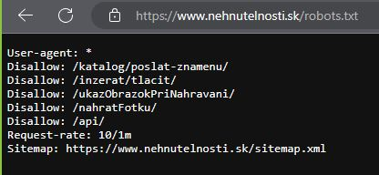